# Target Systolic Blood Pressures Within 115-140mmHg Have Significantly Better Outcomes Than Systolic Blood Pressures >140mmHg

Extended Results for NEJM SPRINT Challenge

Mengyuan Kan (Postdoc in Himes Lab)

Feb 14, 2017

## Introduction

### Summary

SPRINT determined that treating individuals to have systolic blood pressure (SBP) near 120mmHg was better than 140mmHg. Although the average SBP of subjects within treatment groups differed, not all subjects had measures near their target. By grouping subjects according to actual SBP measures, rather than treatment group, we found that those with SBP >140mmHg were at increased risk for cardiovascular disease outcomes, while the risk of those with SBP 115-140mmHg was not substantially different.

#### Original data from SPRINT Challenge

- Baseline measurement for stuey participants: baseline.csv
- Occurance of clinical outcomes during treatment: outcomes.csv
- Occurance of serious adverse events during treatment: safety.csv
- Blood pressure measured in each visit points duringn clinical trial course: bp.csv

## SBP measures over the course of the trial

The mean SBP of subjects during the trial is clearly different randomization. The left figure is the replication of [NEJM paper](http://www.nejm.org/doi/full/10.1056/NEJMoa1511939#t=article%5D) Figure 2 (Bars represent 95% CI). However, comparing with the right figure, where bars represent the standard deviation (SD), SBPs within each treatment group varied largely, and not all the subjects had SBP measures near their targets.

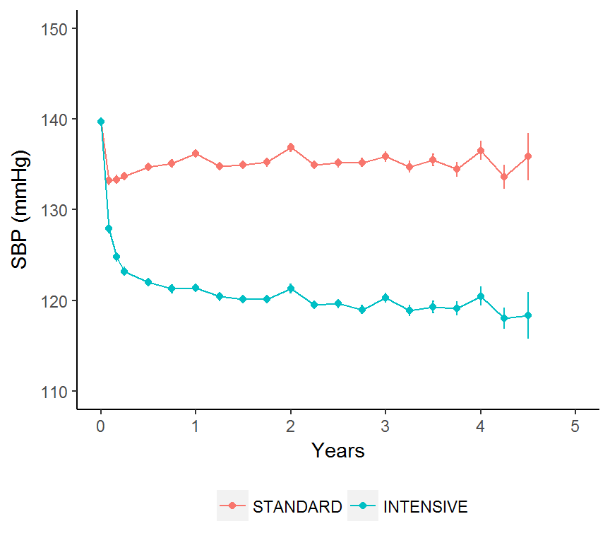

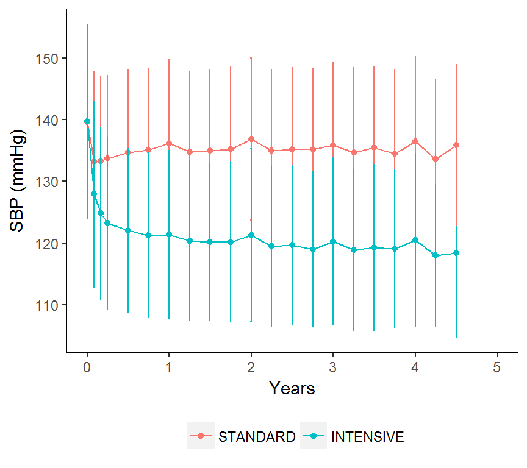

Therefore, our goal was to determine whether an ideal SBP target could be identified, not according to the SPRINT study arms, but by grouping subjects according to their actual SBP measures obtained during the trial.

## Distribution of mean and median trial SBP

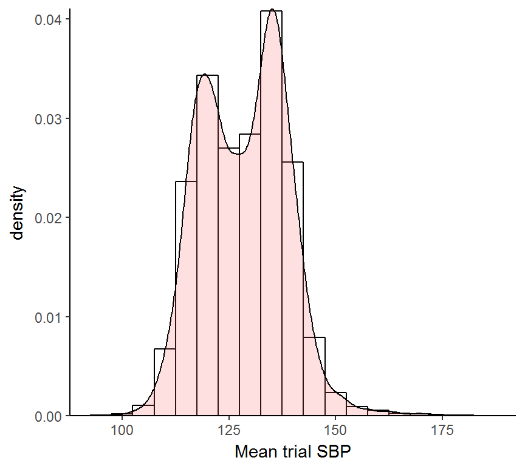

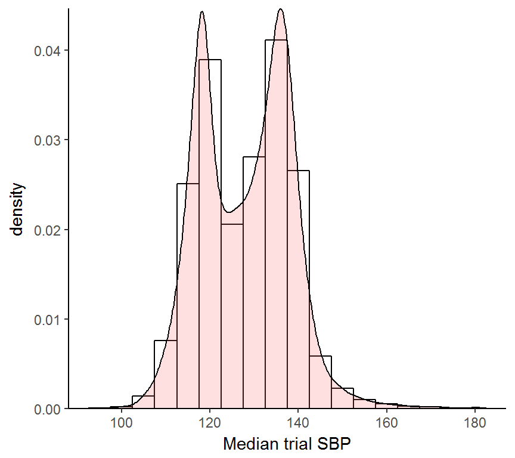

## Splines-based hazard ratio for primary outcome and all-cause death

As outcome variables, we used the trial’s primary outcome variable and all-cause death. Penalized smoothing splines were obtained to assess variability in hazard ratios for each outcome vs. median trial SBP.

### splines-based HR curves

To evaluate possible nonlinear effects of median trial SBP on the course of the clinical outcomes, penalized splines (P-splines, Eilers and Marx) were used that reflect the nature of continuous covariate effects in the additive Cox model. For primary outcome, the smoothed curve showed that LogHR increases slowly up to about 140 mmHg and increases sharply up to about 180 mmHg. While for all-cause death, although the estimates were subject to more error for median trial SBP less than 115 mmHg, logHR decreases sharply to 115 mmHg and increases slowly from 115 mmHg to 140 mmHg, and then dramaticly increases to 180 mmHg. For primary or death outcome, the curve showed the mixed effects of primary outcome and all-cause death.

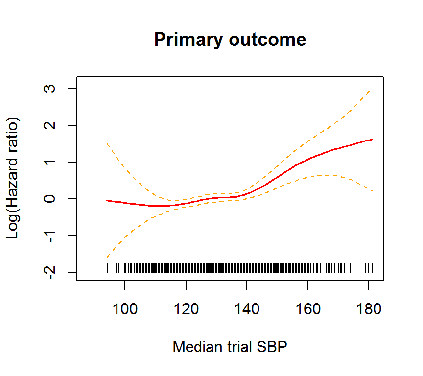

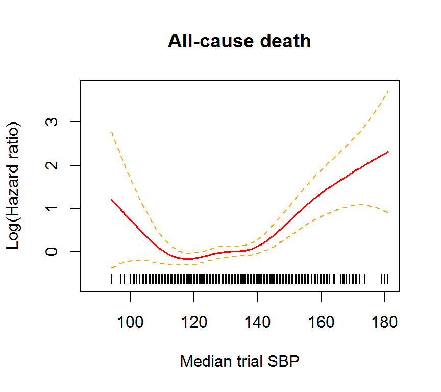

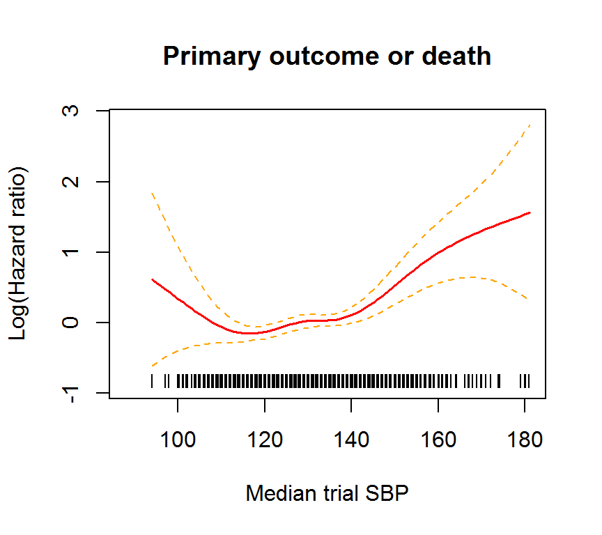

### Cumulative hazard proportion for primary and all-cause death

Cumulative hazard proportion was plotted for <115 mmHg, 115-140 mmHg and >140 mmHg. The separation in primary outcome between >140 mmHg group and the other two groups were apparent at 1 year, and in all-cause death became apparent at 2 years, indicating the difference in cumulative hazards in >140 mmHg compared with the other two groups.

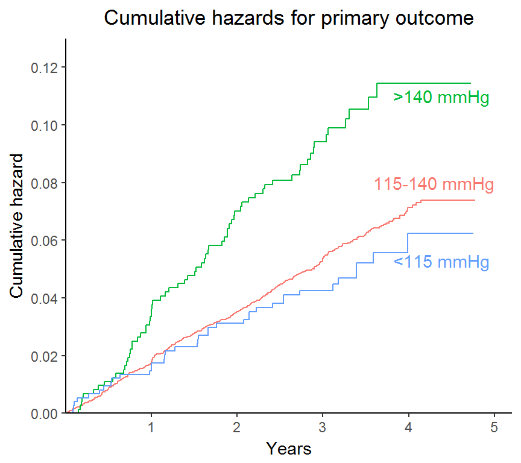

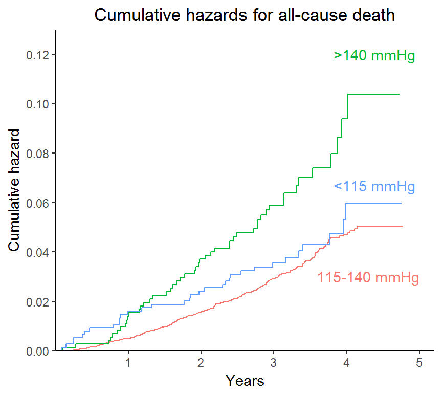

### Cox proportional HR in <115 mmHg, 115-140 mmHg and >140 mmHg groups

#### Primary outcome

| group | Event/Total(%) | Intensive arm/Total(%) | HR (95%CI) | P value |
| --- | --- | --- | --- | --- |
| <115 mmHg | 37/753(4.91) | 707/753(93.89) | 0.83(0.6-1.17) | 0.29 |
| 115-140 mmHg | 447/7740(5.78) | 3780/7740(48.84) | 1 | NA |
| >140 mmHg | 69/755(9.14) | 145/755(19.21) | 1.75(1.36-2.26) | 1.49e-05 |

##### All-cause death

| group | Event/Total(%) | Intensive arm/Total(%) | HR (95%CI) | P value |
| --- | --- | --- | --- | --- |
| <115 mmHg | 32/753(4.25) | 707/753(93.89) | 1.19(0.82-1.71) | 0.36 |
| 115-140 mmHg | 270/7740(3.49) | 3780/7740(48.84) | 1 | NA |
| >140 mmHg | 48/755(6.36) | 145/755(19.21) | 2.02(1.49-2.75) | 6.89e-06 |

### Cox proportional HR in <115 mmHg, 115-140 mmHg and >140 mmHg groups according to subphenotypes

For p-values for interaction, an interaction term with SBP partition category by subgroup was added in the model. The p-value in each subgroup was adjusted for interaction effects using Hommel’s method. P-values shown in the table were the interaction between the >140 mmHg group and subgroups, while it was shown repeatedly for each subgroup for visualization purpose.

#### Primary outcome

Number of events in each subgroup

| subgroup | 115-140 mmHg | <115 mmHg | >140 mmHg |
| --- | --- | --- | --- |
| Overall | 447/7740(5.78) | 37/753(4.91) | 69/755(9.14) |
| NonCKD | 264/5609(4.71) | 22/549(4.01) | 38/482(7.88) |
| CKD | 183/2131(8.59) | 15/204(7.35) | 31/273(11.36) |
| <75yr | 255/5590(4.56) | 24/580(4.14) | 31/480(6.46) |
| >=75yr | 192/2150(8.93) | 13/173(7.51) | 38/275(13.82) |
| Nonblack | 337/5357(6.29) | 27/524(5.15) | 48/474(10.13) |
| Black | 110/2383(4.62) | 10/229(4.37) | 21/281(7.47) |
| MALE | 323/5074(6.37) | 22/457(4.81) | 42/436(9.63) |
| FEMALE | 124/2666(4.65) | 15/296(5.07) | 27/319(8.46) |
| NonCVD | 282/6217(4.54) | 27/584(4.62) | 43/594(7.24) |
| CVD | 165/1523(10.83) | 10/169(5.92) | 26/161(16.15) |
| <=132mmHg | 141/2600(5.42) | 17/393(4.33) | 8/107(7.48) |
| 132-145mmHg | 148/2594(5.71) | 16/210(7.62) | 16/197(8.12) |
| >=145mmHg | 158/2546(6.21) | 4/150(2.67) | 45/451(9.98) |

Proportional HR (95% CI) in each subgroup

| subgroup | <115 mmHg | >140 mmHg | P value for interaction |
| --- | --- | --- | --- |
| Overall | 0.83(0.6-1.17) | 1.75(1.36-2.26) | NA |
| NonCKD | 0.83(0.54-1.28) | 1.9(1.35-2.67) | 0.61 |
| CKD | 0.85(0.5-1.44) | 1.39(0.95-2.04) | 0.61 |
| <75yr | 0.89(0.58-1.35) | 1.58(1.09-2.3) | 0.89 |
| >=75yr | 0.84(0.48-1.48) | 1.65(1.17-2.34) | 0.89 |
| Nonblack | 0.81(0.54-1.19) | 1.74(1.29-2.36) | 0.83 |
| Black | 0.92(0.48-1.75) | 1.87(1.17-2.98) | 0.83 |
| MALE | 0.75(0.48-1.15) | 1.67(1.21-2.3) | 0.45 |
| FEMALE | 1.06(0.62-1.81) | 2.04(1.35-3.1) | 0.45 |
| NonCVD | 1(0.67-1.49) | 1.79(1.3-2.47) | 1 |
| CVD | 0.53(0.28-1) | 1.56(1.03-2.35) | 1 |
| <=132mmHg | 0.78(0.47-1.29) | 1.6(0.79-3.27) | 0.93 |
| 132-145mmHg | 1.32(0.79-2.2) | 1.53(0.92-2.57) | 0.93 |
| >=145mmHg | 0.42(0.16-1.14) | 1.77(1.27-2.46) | 0.93 |

#### All-cause death

Number of events in each subgroup

| subgroup | 115-140 mmHg | <115 mmHg | >140 mmHg |
| --- | --- | --- | --- |
| Overall | 270/7740(3.49) | 32/753(4.25) | 48/755(6.36) |
| NonCKD | 153/5609(2.73) | 17/549(3.1) | 26/482(5.39) |
| CKD | 117/2131(5.49) | 15/204(7.35) | 22/273(8.06) |
| <75yr | 142/5590(2.54) | 14/580(2.41) | 22/480(4.58) |
| >=75yr | 128/2150(5.95) | 18/173(10.4) | 26/275(9.45) |
| Nonblack | 187/5357(3.49) | 27/524(5.15) | 33/474(6.96) |
| Black | 83/2383(3.48) | 5/229(2.18) | 15/281(5.34) |
| MALE | 194/5074(3.82) | 23/457(5.03) | 35/436(8.03) |
| FEMALE | 76/2666(2.85) | 9/296(3.04) | 13/319(4.08) |
| NonCVD | 183/6217(2.94) | 25/584(4.28) | 29/594(4.88) |
| CVD | 87/1523(5.71) | 7/169(4.14) | 19/161(11.8) |
| <=132mmHg | 82/2600(3.15) | 17/393(4.33) | 5/107(4.67) |
| 132-145mmHg | 81/2594(3.12) | 8/210(3.81) | 12/197(6.09) |
| >=145mmHg | 107/2546(4.2) | 7/150(4.67) | 31/451(6.87) |

Proportional HR (95% CI) in each subgroup

| subgroup | <115 mmHg | >140 mmHg | P value for interaction |
| --- | --- | --- | --- |
| Overall | 1.19(0.82-1.71) | 2.02(1.49-2.75) | NA |
| NonCKD | 1.1(0.67-1.82) | 2.26(1.49-3.42) | 0.7 |
| CKD | 1.32(0.77-2.26) | 1.56(0.99-2.46) | 0.7 |
| <75yr | 0.92(0.53-1.6) | 2.03(1.3-3.19) | 0.77 |
| >=75yr | 1.75(1.07-2.87) | 1.68(1.1-2.56) | 0.77 |
| Nonblack | 1.45(0.97-2.17) | 2.15(1.48-3.11) | 0.99 |
| Black | 0.6(0.24-1.48) | 1.8(1.04-3.12) | 0.99 |
| MALE | 1.3(0.84-2) | 2.34(1.63-3.36) | 0.53 |
| FEMALE | 1.02(0.51-2.04) | 1.59(0.89-2.87) | 0.53 |
| NonCVD | 1.41(0.93-2.15) | 1.87(1.27-2.77) | 0.7 |
| CVD | 0.71(0.33-1.54) | 2.14(1.3-3.51) | 0.7 |
| <=132mmHg | 1.33(0.79-2.24) | 1.76(0.72-4.35) | 0.96 |
| 132-145mmHg | 1.18(0.57-2.44) | 2.11(1.15-3.86) | 0.96 |
| >=145mmHg | 1.1(0.51-2.37) | 1.8(1.21-2.69) | 0.96 |

### Cox proportional HR in <115 mmHg, 115-130 mmHg, 131-140 mmHg and >140 mmHg groups

#### Primary outcome

| group | Event/Total(%) | Intensive arm/Total(%) | HR (95%CI) | P value |
| --- | --- | --- | --- | --- |
| <115 mmHg | 37/753(4.91) | 707/753(93.89) | 0.86(0.61-1.22) | 0.41 |
| 115-130 mmHg | 240/4320(5.56) | 3339/4320(77.29) | 1 | NA |
| 131-140 mmHg | 207/3420(6.05) | 441/3420(12.89) | 1.08(0.9-1.3) | 0.4 |
| >140 mmHg | 69/755(9.14) | 145/755(19.21) | 1.82(1.39-2.37) | 1.28e-05 |

#### All-cause death

| group | Event/Total(%) | Intensive arm/Total(%) | HR (95%CI) | P value |
| --- | --- | --- | --- | --- |
| <115 mmHg | 32/753(4.25) | 707/753(93.89) | 1.21(0.82-1.77) | 0.34 |
| 115-130 mmHg | 148/4320(3.43) | 3339/4320(77.29) | 1 | NA |
| 131-140 mmHg | 122/3420(3.57) | 441/3420(12.89) | 1.03(0.81-1.31) | 0.78 |
| >140 mmHg | 48/755(6.36) | 145/755(19.21) | 2.05(1.48-2.84) | 1.48e-05 |

## Splines-based hazard ratio for serious adverse events (SAEs)

From Table 3 of [NEJM paper](http://www.nejm.org/doi/full/10.1056/NEJMoa1511939#t=article%5D), the rate of total SAEs in participants in the intensive treatment is significantly higher than that in the standard treatment. We also plotted the smooth spline curves for various SAEs and evaluated variability in HRs for total SAEs vs median trial SBP.

### Splines-based HR curves on total SAE

The curve below shows that overall, the rate of total SAEs did not vary too much within 115-140 although there was a slight increase near 130 mmHg.

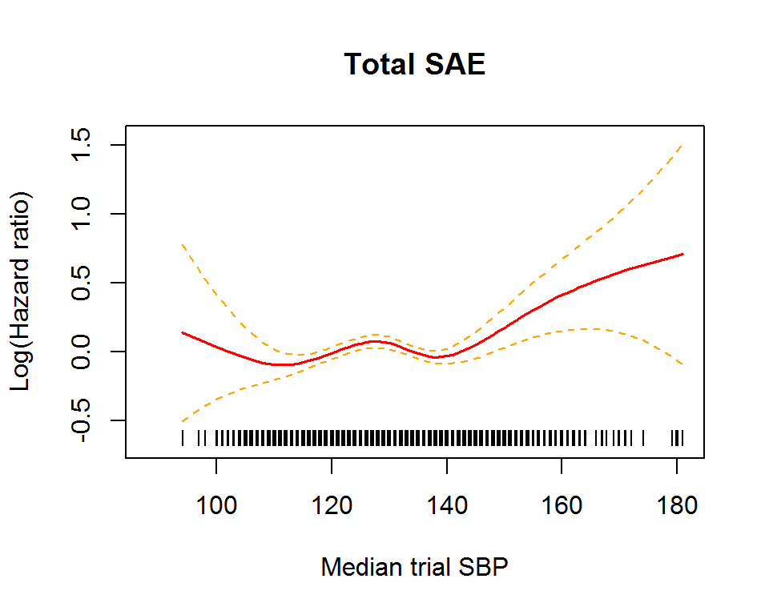

We computed proportional HRs for SAEs versis median trial SBP groups using the same partitions as for primary outcome or all-cause death outcome.

### Cox proportional HRs in <115 mmHg, 115-140 mmHg, and >140 mmHg groups

Relative to 115-140 mmHg group, >140 mmHg group had a significant higher rate of SAE outcome.

| group | Event/Total(%) | Intensive arm/Total(%) | HR (95%CI) | P value |
| --- | --- | --- | --- | --- |
| <115 mmHg | 278/753(36.92) | 707/753(93.89) | 0.96(0.85-1.08) | 0.49 |
| 115-140 mmHg | 2917/7740(37.69) | 3780/7740(48.84) | 1 | NA |
| >140 mmHg | 306/755(40.53) | 145/755(19.21) | 1.2(1.06-1.35) | 0.00285 |

### Cox proportional HRs in <115 mmHg, 115-130 mmHg, 131-140 mmHg and >140 mmHg groups

Similarly, relative to 115-130 mmHg group, >140 mmHg group had a significant higher rate of SAE outcome. However, 131-140 mmHg group had a lower rate of SAE outcome which could reflect as a local minimum at 140 mmHg in the smoothed curve.

| group | Event/Total(%) | Intensive arm/Total(%) | HR (95%CI) | P value |
| --- | --- | --- | --- | --- |
| <115 mmHg | 278/753(36.92) | 707/753(93.89) | 0.92(0.81-1.04) | 0.2 |
| 115-130 mmHg | 1677/4320(38.82) | 3339/4320(77.29) | 1 | NA |
| 131-140 mmHg | 1240/3420(36.26) | 441/3420(12.89) | 0.91(0.85-0.98) | 0.01 |
| >140 mmHg | 306/755(40.53) | 145/755(19.21) | 1.15(1.02-1.3) | 0.03 |

### Splines-based HR curves on other SAEs

The curves in the plots below (ER represents emergency room visit) for specific SAEs were different than that for total SAE, as expected based on their different nature. For example, it is not surprising that risk of hypotension increased with the decrease in SBPs.

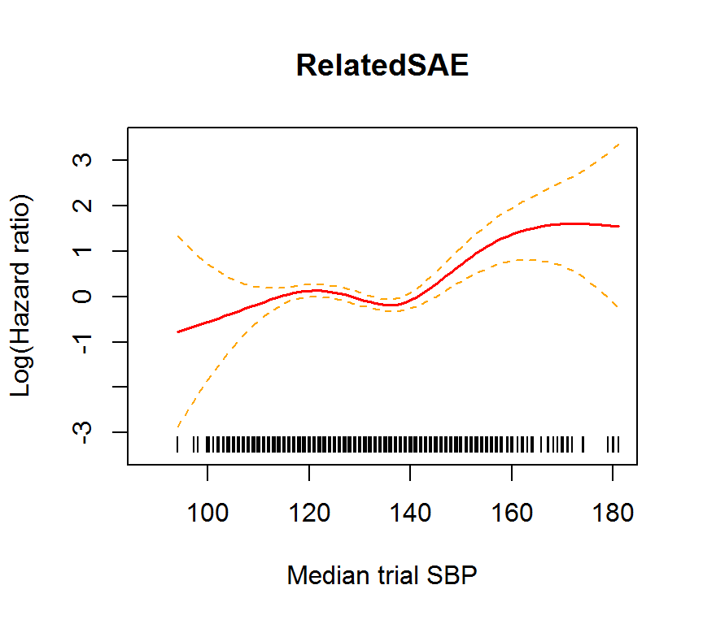

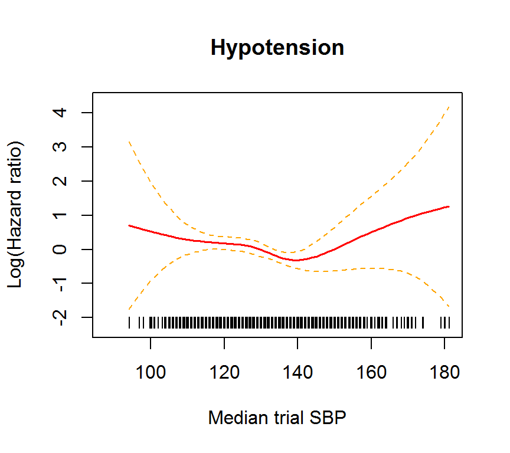

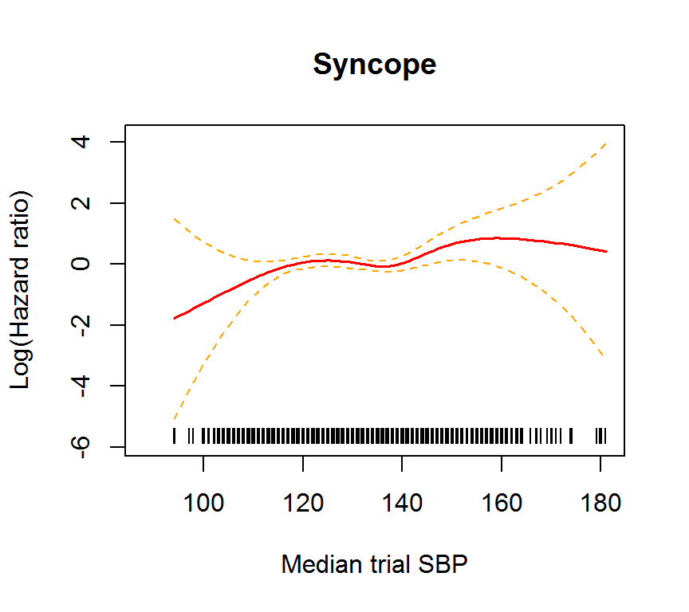

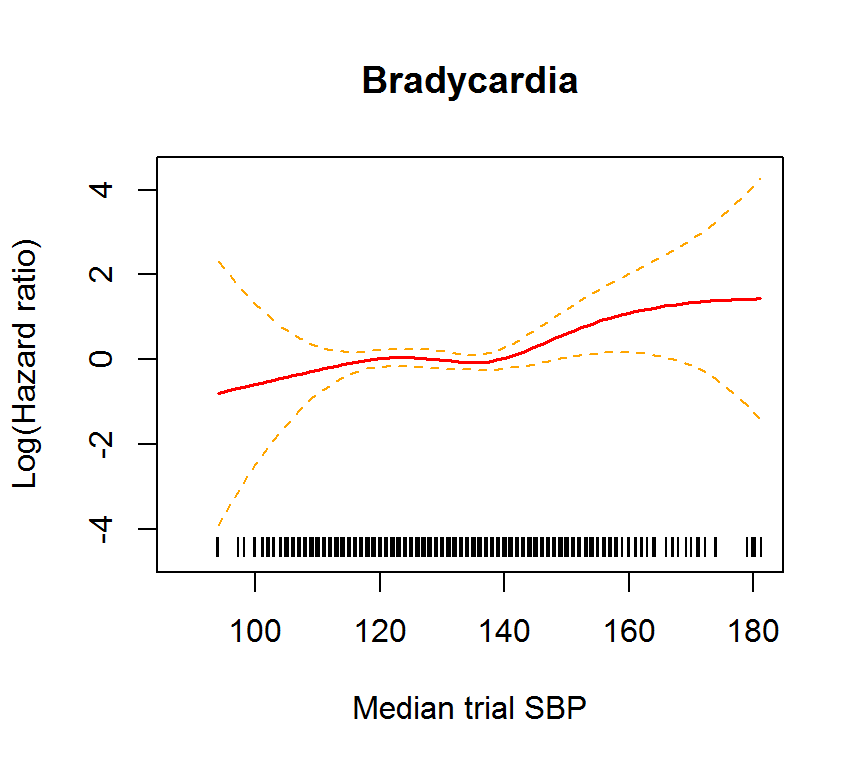

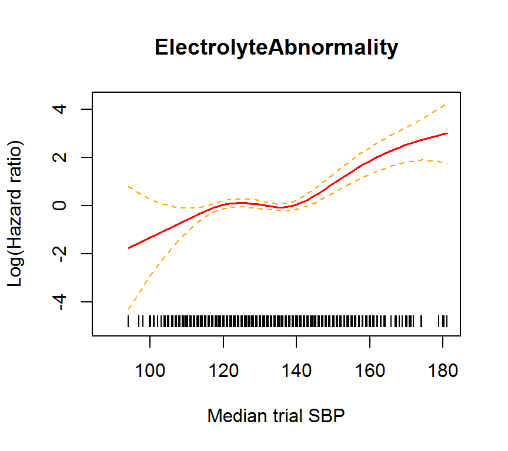

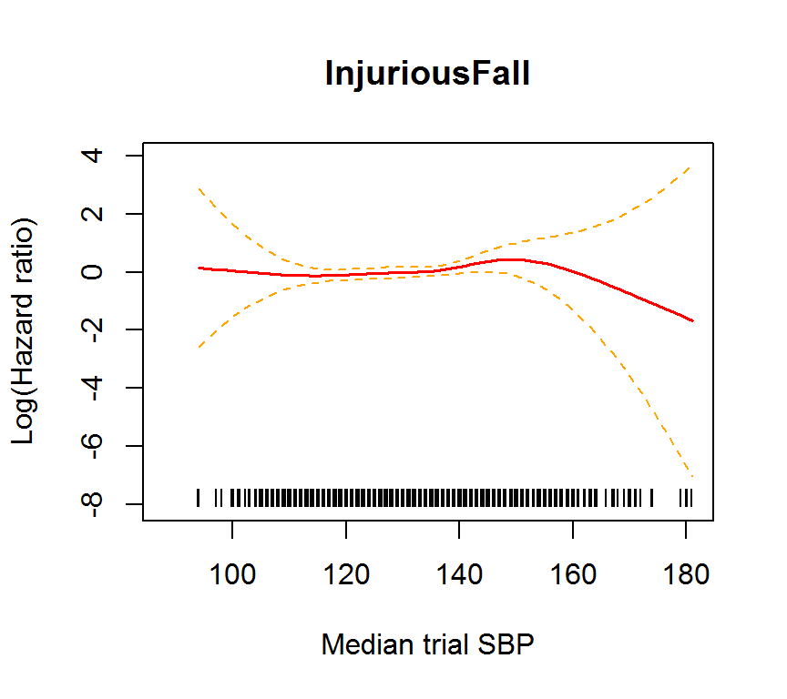

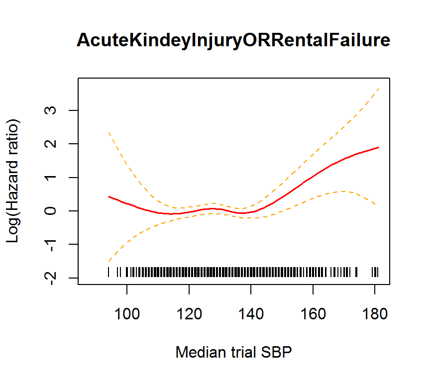

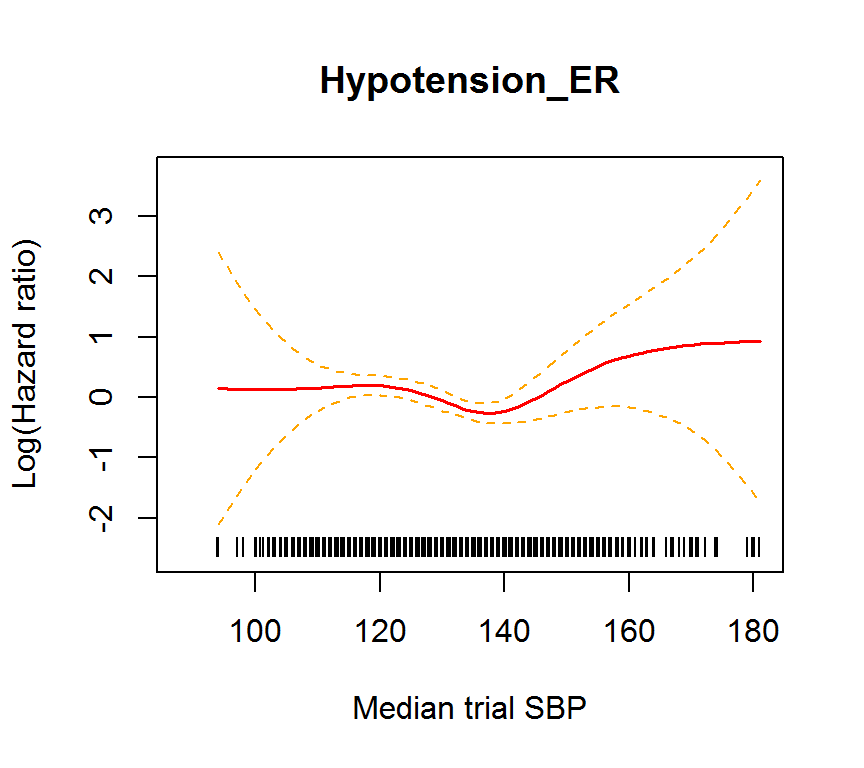

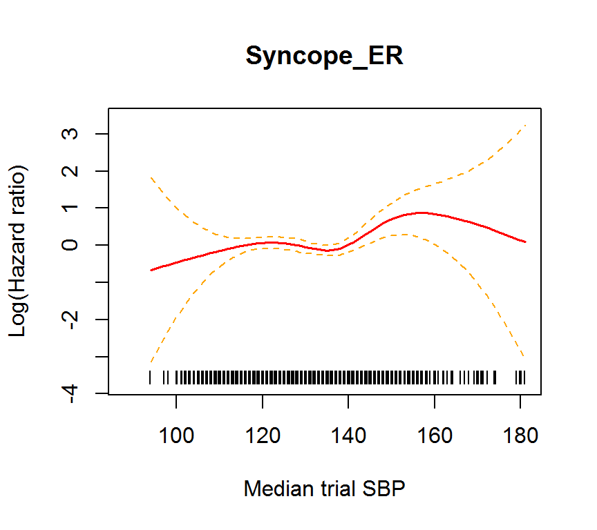

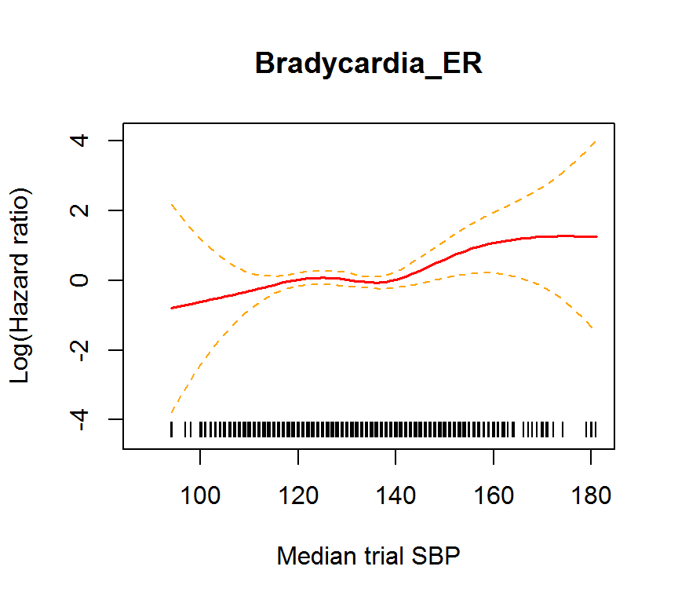

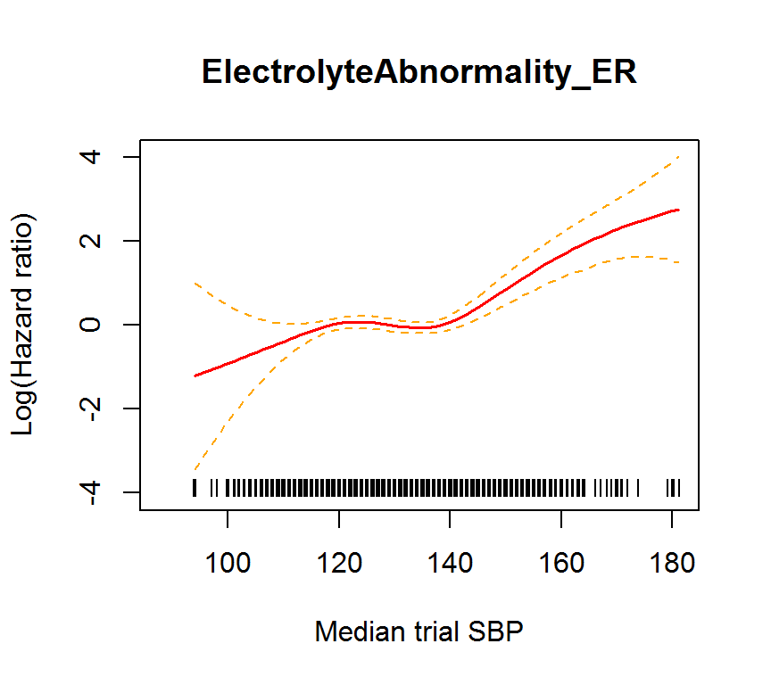

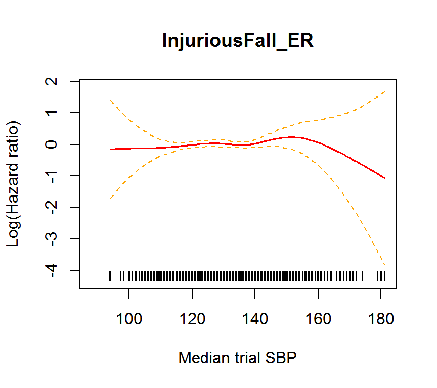

[7 more figures not shown]

## Spline-based SBP associations with CVD risk in NHANES

To assess whether ideal SBP differed over a wider range of values and to other age groups, we used 2007-2014 data from the [National Health and Nutrition Examination Survey (NHANES)](https://www.cdc.gov/nchs/nhanes/), a cross-sectional study that includes extensive in-person interviews and physical exams. We created a composite cardiovascular disease (CVD) outcome by assigning case status to subjects who had congestive heart failure, coronary heart disease, angina, heart attack, and or stroke, and control status to those who did not have any of those outcomes.

2007-2014 NHANES data were downloaded and cleaned using R codes from NHANES_SPRINT.rmd. There are 23,482 adults 20 years old or greater, with 10,704 participants 50 years old or greater and 3,719 at age of 40-50 years old. Among senior adults 50 years or greater, 2,255 are diabetic and 8,085 are non-diabetic.

### Splines-based OR curves

In senior participants 50 years old or greater (the left figure), the smoothed curve showed logOR decreases sharply to 120 mmHg and then slowly increased. In the relatively younger participants 40-50 years old (the right figure), the logOR decreases sharply to 115 mmHg but increased sharply.

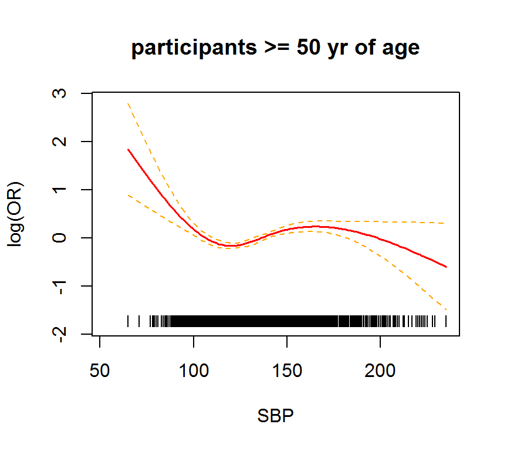

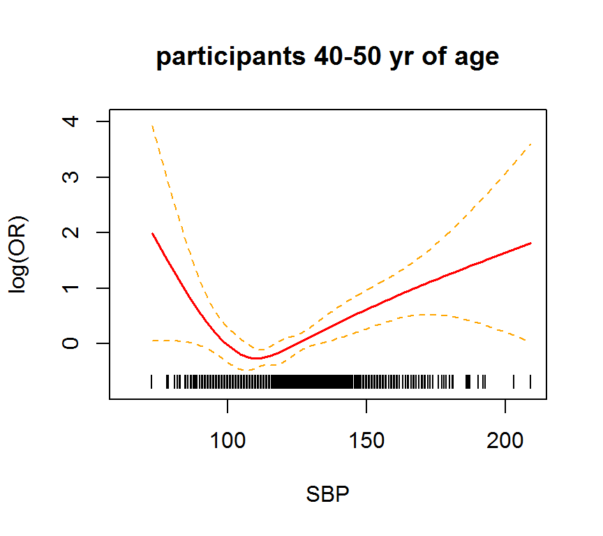

As SPRINT only included senior and nondiabetic participants while NHANES contains both nondiabetic and diabetic participants, we evaluated CVD risk in non-diabetic and diabetic participants separatedly. In both senior nondiabetic (the left figure) and diabetic participants (the right figure), the lowest logOR was shown at 120 mmHg, while in nondiabetic participants the curve decreased sharply in the region of SBP <120 mmHg compared to that in diabetic participants.

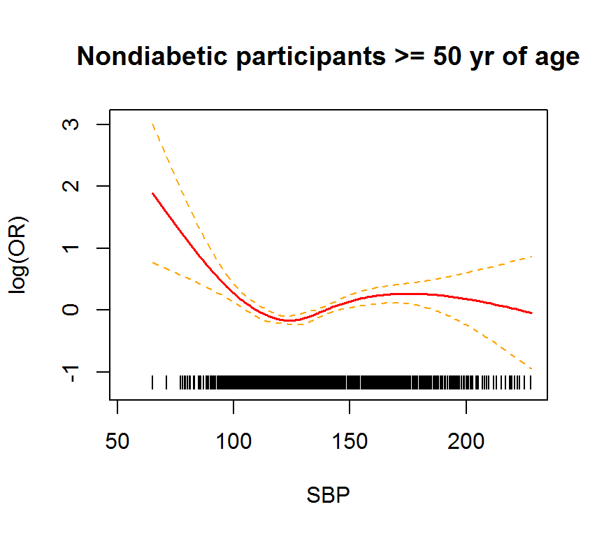

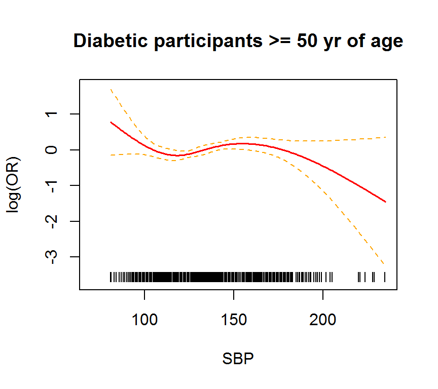

### ORs in <115 mmHg, 115-130 mmHg, 131-140 mmHg and >140 mmHg groups

According to the smoothed curve, SBPs in NHANES can be partitioned into the same group as for SPRINT data <115 mmHg, 115-130mmHg, 131-140 mmHg and >140 mmHg, which is also comparable to SPRINT results. Because of the lowest logOR in 115-130mmHg, this group was chosen as a reference group. ORs of CVD risk in each partition groups were computed.

#### Participants >=50 yr of age

| group | CVD/Total(%) | OR (95%CI) | P value |
| --- | --- | --- | --- |
| <115 mmHg | 396/2065(19.18) | 1.17(1-1.38) | 0.06 |
| 115-130 mmHg | 651/3659(17.79) | 1 | NA |
| 131-140 mmHg | 391/2017(19.39) | 1.21(0.99-1.47) | 0.06 |
| >140 mmHg | 628/2904(21.63) | 1.46(1.24-1.71) | 2.27e-05 |

#### Participants 40-50 yr of age

| group | CVD/Total(%) | OR (95%CI) | P value |
| --- | --- | --- | --- |
| <115 mmHg | 56/1459(3.84) | 0.86(0.55-1.32) | 0.49 |
| 115-130 mmHg | 65/1514(4.29) | 1 | NA |
| 131-140 mmHg | 22/391(5.63) | 1.18(0.66-2.12) | 0.58 |
| >140 mmHg | 29/335(8.66) | 1.92(1.09-3.39) | 0.03 |

#### Nondiabetic participants >=50 yr of age

| group | CVD/Total(%) | OR (95%CI) | P value |
| --- | --- | --- | --- |
| <115 mmHg | 270/1636(16.5) | 1.35(1.12-1.62) | 2.47e-03 |
| 115-130 mmHg | 401/2811(14.27) | 1 | NA |
| 131-140 mmHg | 217/1487(14.59) | 1.22(0.99-1.5) | 0.07 |
| >140 mmHg | 377/2116(17.82) | 1.61(1.33-1.94) | 5.28e-06 |

#### Diabetic participants >=50 yr of age

| group | CVD/Total(%) | OR (95%CI) | P value |
| --- | --- | --- | --- |
| <115 mmHg | 112/373(30.03) | 0.95(0.64-1.39) | 0.78 |
| 115-130 mmHg | 223/725(30.76) | 1 | NA |
| 131-140 mmHg | 154/453(34) | 0.96(0.65-1.4) | 0.82 |
| >140 mmHg | 224/685(32.7) | 0.97(0.7-1.35) | 0.86 |

## Conclusion

Subjects whose median trial SBP was within 115-140mmHg had nearly the same primary outcome and all-cause death rates, while those with medial trial SBP >140mmHg had higher rates of events. Thus, while SPRINT suggests that an SBP target of 120mmHg was better than 140mmHg, a target greater than 120mmHg may be just as beneficial while requiring fewer medications.